# Candy Case Study – Lidl Data & AI

## 🔍 Cluster analysis

For a better understanding of the main types of candies in the market, we may apply a factor analysis.

```r
# Keep only numeric variables
df_cluster <- candy_data %>% dplyr::select(
  -competitorname,
  -producer,
  -winperc,
  -pricepercent,
  -num_features
)

# Standardize
df_scaled <- scale(df_cluster)

# Factor analysis
fit <- factanal(df_scaled, factors = 4)

# Summary
fit
```

```
Call:
factanal(x = df_scaled, factors = 4)

Uniquenesses:
       chocolate           fruity          caramel   peanutyalmondy
           0.336            0.005            0.813            0.761
          nougat crispedricewafer             hard              bar
           0.005            0.656            0.641            0.071
        pluribus        sugarperc
           0.581            0.005

Loadings:
                 Factor1 Factor2 Factor3 Factor4
chocolate         0.662   0.399  -0.232   0.110
fruity           -0.941  -0.227   0.209  -0.116
caramel           0.273   0.170  -0.103   0.271
peanutyalmondy    0.335          -0.320   0.141
nougat            0.140                   0.982
crispedricewafer  0.175   0.529          -0.171
hard             -0.260  -0.101   0.526
bar               0.289   0.811  -0.148   0.407
pluribus         -0.105  -0.573   0.123  -0.254
sugarperc                -0.150   0.982

               Factor1 Factor2 Factor3 Factor4
SS loadings      1.733   1.551   1.496   1.347
Proportion Var   0.173   0.155   0.150   0.135
Cumulative Var   0.173   0.328   0.478   0.613

Test of the hypothesis that 4 factors are sufficient.
The chi square statistic is 15.99 on 11 degrees of freedom.
The p-value is 0.142
```

Interpretation:

- Four factors seem like enough, even though the variance explained is rather low and the uniqueness is rather high for some features.
- The four factors can be described as follows:
  1. Chocolate with caramel and nuts as a bar but not fruity or pluribus
  2. Mostly cookie-based without nougat or nut but with chocolate as a single bar and with only a little sugar
  3. Hard and fruity with a lot of sugar
  4. Nougat bars with caramel

## 🌲 Random Forest

A random forest might be able to better adapt to non-linearities in the data.

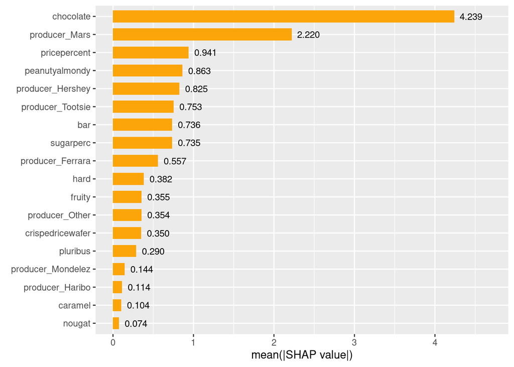

```r
set.seed(123)
# Prepare data
df <- candy_data %>%
  fastDummies::dummy_cols("producer", remove_selected_columns = TRUE) %>%
  dplyr::select(-competitorname, -num_features)

X <- df %>% dplyr::select(-winperc)
y <- df$winperc

# Fit Random Forest
rf_model <- ranger(winperc ~ ., data = cbind(X, winperc = y), num.trees = 500)

# Create prediction wrapper
pred_fun <- function(m, newdata) predict(m, data = newdata)$predictions

# Compute SHAP values via kernelshap
shap_out <- kernelshap(
  object = rf_model,
  X = X,
  pred_fun = pred_fun,
  verbose = FALSE
)

# Convert to shapviz object
sv <- shapviz(shap_out)

# Feature Importance
sv_importance(sv, show_numbers = TRUE, max_display = 20)
```

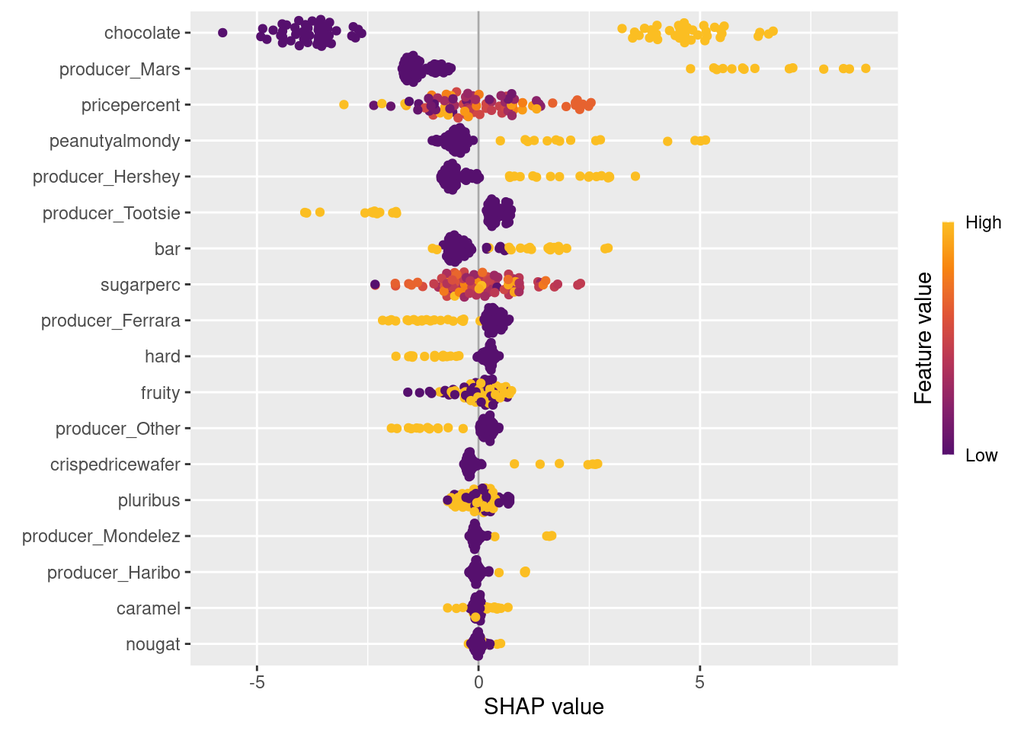

```r
# SHAP values
sv_importance(sv, kind = "beeswarm", max_display = 20)
```

Interpretation:

## 🧮 BMA

Until now, we only used frequentist approaches. We also might use Bayesian statistics.

```r
set.seed(123)
bma_data <- candy_data %>%
  dplyr::select(-competitorname, -num_features) %>%
  mutate(
    pricepercent_sq = pricepercent^2,
    sugarperc_sq = sugarperc^2
  )

# BMA model
bma_model <- bicreg(x = bma_data %>% dplyr::select(-winperc), y = bma_data$winperc, strict = FALSE)

# Summary
summary(bma_model)
```

```
Call:
bicreg(x = bma_data %>% dplyr::select(-winperc), y = bma_data$winperc,     strict = FALSE)


  153  models were selected
 Best  5  models (cumulative posterior probability =  0.1795 ):

                  p!=0    EV        SD      model 1  model 2  model 3  model 4
Intercept         100.0  38.202958  4.4207   41.524   40.256   36.349   34.968
producerHaribo     10.0   0.659767  2.5528      .        .        .        .
producerHershey    81.9   7.574212  4.8181    7.831   10.573    8.455   11.154
producerMars      100.0  15.511248  3.9022   15.418   17.879   15.390   17.797
producerMondelez   15.2   1.143923  3.3628      .        .        .        .
producerOther       8.9  -0.386636  1.6225      .        .        .        .
producerTootsie    57.4  -4.506543  4.7419   -7.164      .     -7.013      .
chocolate         100.0  15.240818  4.1048   13.218   11.547   17.951   16.445
fruity             48.5   3.411138  4.2648      .        .      6.379    6.552
caramel             3.0   0.034000  0.6083      .        .        .        .
peanutyalmondy     29.6   1.759430  3.2593      .        .        .        .
nougat              2.5  -0.048547  0.7343      .        .        .        .
crispedricewafer   18.6   1.205419  3.1103      .        .        .        .
hard                4.8  -0.136773  0.9386      .        .        .        .
bar                 2.3   0.003911  0.4782      .        .        .        .
pluribus            2.4  -0.017038  0.3749      .        .        .        .
pricepercent        6.5   1.148843  6.4603      .        .        .        .
sugarperc           2.8   0.005502  1.3189      .        .        .        .
pricepercent_sq     8.9  -1.443971  6.8960      .        .        .        .
sugarperc_sq        2.7   0.012597  1.0017      .        .        .        .

nVar                                            4        3        5        4
r2                                            0.599    0.574    0.617    0.594
BIC                                         -58.124  -57.645  -57.623  -57.125
post prob                                     0.048    0.038    0.037    0.029
                  model 5
Intercept          42.541
producerHaribo        .
producerHershey       .
producerMars       11.845
producerMondelez      .
producerOther         .
producerTootsie    -9.970
chocolate          16.796
fruity                .
caramel               .
peanutyalmondy        .
nougat                .
crispedricewafer      .
hard                  .
bar                   .
pluribus              .
pricepercent          .
sugarperc             .
pricepercent_sq       .
sugarperc_sq          .

nVar                  3
r2                  0.571
BIC               -57.081
post prob           0.028
```

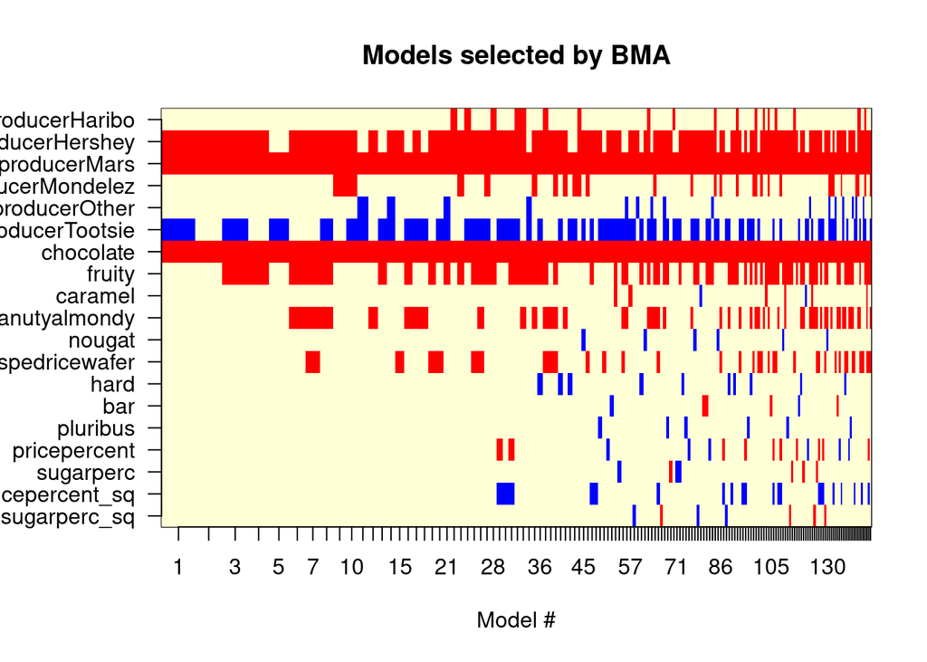

```r
# Visualize
imageplot.bma(bma_model)
```

Interpretation:

- Blue cells symbolize negative coefficients, red cells symbolize positive coefficients. The larger a cell, the higher the posterior probability.
- Almost all variables only have one color, indicating that the estimation is robust regarding the direction of the coefficients.
- Again, the variables chocolate, fruity, nut and cookie-based seem to have the most consistent, positive influence.

## ⚡ XGBoost Regression

XGBoost is relatively new but very popular machine-learning technique that also can be used to estimate variable importance.

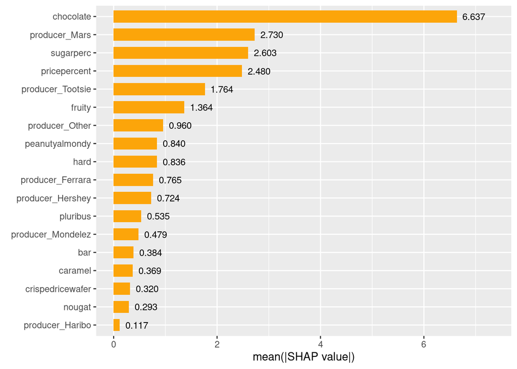

```r
set.seed(123)

# Prepare data
xgb_data <- candy_data %>%
  fastDummies::dummy_cols(., c("producer"), remove_selected_columns = TRUE) %>%
  dplyr::select(-competitorname, -winperc, -num_features)

# Train model
params <- list(objective = "reg:squarederror", eval_metric = "rmse")
xgb_model <- xgb.train(
  params = params,
  data = xgb.DMatrix(
    data = as.matrix(xgb_data),
    label = candy_data$winperc
  ),
  nrounds = 100
)

# Calculate SHAP values
shp <- shapviz(xgb_model, X_pred = data.matrix(xgb_data), X = xgb_data)

# Show feature importance
sv_importance(shp, show_numbers = TRUE, max_display = 20)
```

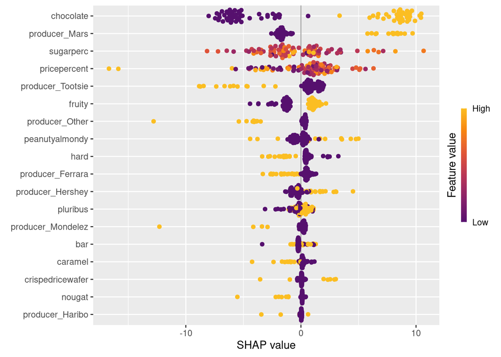

```r
# Show SHAP values
sv_importance(shp, kind = "beeswarm", max_display = 20)
```